# CodingChallenge5

Radhika

2026-03-05

```r
df1<- read.csv("DiversityData.csv")
df2<- read.csv("Metadata.csv")
library(tidyverse)
#joining the two df by code
alpha<- inner_join(df1, df2, by ="Code")

#3.Calculate Pielou’s evenness index: Pielou’s evenness is an ecological parameter calculated by
#the Shannon diversity index (column Shannon) divided by the log of the richness column.
#a. Using mutate, create a new column to calculate Pielou’s evenness index.
#b. Name the resulting dataframe alpha_even.

alpha_even<- mutate(alpha, even= shannon/log(richness))
alpha_even
```

```
##        Code  shannon invsimpson   simpson richness    Crop Time_Point Replicate
## 1    S01_13 6.624921  210.72795 0.9952545     3319    Soil          0         1
## 2    S02_16 6.612413  206.86664 0.9951660     3079    Soil          0         2
## 3    S03_19 6.660853  213.01843 0.9953056     3935    Soil          0         3
## 4    S04_22 6.660671  204.69080 0.9951146     3922    Soil          0         4
## 5    S05_25 6.610965  200.25523 0.9950064     3196    Soil          0         5
## 6    S06_28 6.650812  199.32110 0.9949830     3481    Soil          0         6
## 7    S61_32 6.570679  200.23177 0.9950058     3250    Soil          6         1
## 8    S62_35 6.492227  171.27965 0.9941616     3170    Soil          6         2
## 9    S63_38 6.610986  192.08535 0.9947940     3657    Soil          6         3
## 10   S64_41 6.472259  163.99814 0.9939024     3177    Soil          6         4
## 11   S65_44 6.508824  181.69248 0.9944962     2985    Soil          6         5
## 12   S66_47 6.482495  176.90684 0.9943473     2770    Soil          6         6
## 13  S121_51 6.276073  126.56259 0.9920988     3040    Soil         12         1
## 14  S122_54 6.461118  152.98152 0.9934633     3192    Soil         12         2
```

[output cut: 127 more lines]

```r
#4. Using tidyverse language of functions and the pipe, use the summarise function and tell me
#the mean and standard error evenness grouped by crop over time.
library(tidyverse)
alpha_average<- alpha_even %>%
  group_by(Crop, Time_Point)%>%
  summarise(mean.even= mean(even),
            n = n(),
            sd.dev = sd(even))%>%
  mutate(std.err = sd.dev/sqrt(n))
```

Calculate the difference between the soybean column, the soil column, and the difference between the cotton column and the soil column a. Start with the alpha_average dataframe b. Select relevant columns: select the columns Time_Point, Crop, and mean.even. c. Reshape the data: Use the pivot_wider function to transform the data from long to wide format, creating new columns for each Crop with values from mean.even. d. Calculate differences: Create new columns named diff.cotton.even and diff.soybean.even by calculating the difference between Soil and Cotton, and Soil and Soybean, respectively. e. Name the resulting dataframe alpha_average2

```r
alpha_average2<- alpha_average%>%
  select(Time_Point, Crop, mean.even)%>%
  pivot_wider(names_from = Crop, values_from = mean.even)%>%
  mutate(diff.cotton.even = Soil - Cotton)%>%
  mutate(diff.soybean.even = Soil - Soybean)
alpha_average2
```

```
## # A tibble: 4 × 6
##   Time_Point Cotton  Soil Soybean diff.cotton.even diff.soybean.even
##        <int>  <dbl> <dbl>   <dbl>            <dbl>             <dbl>
## 1          0  0.820 0.814   0.822         -0.00602          -0.00740
## 2          6  0.805 0.810   0.764          0.00507           0.0459
## 3         12  0.767 0.798   0.687          0.0313            0.112
## 4         18  0.755 0.800   0.716          0.0449            0.0833
```

Connecting it to plots a. Start with the alpha_average2 dataframe b. Select relevant columns: select the columns Time_Point, diff.cotton.even, and diff.soybean.even. c. Reshape the data: Use the pivot_longer function to transform the data from wide to long format, creating a new column named diff that contains the values from diff.cotton.even and diff.soybean.even. i. This might be challenging, so I’ll give you a break. The code is below. pivot_longer(c(diff.cotton.even, diff.soybean.even), names_to = “diff”) d. Create the plot: Use ggplot and geom_line() with ‘Time_Point’ on the x-axis, the column ‘values’ on the y-axis, and different colors for each ‘diff’ category. The column named ‘values’ come from the pivot_longer. The resulting plot should look like the one to the right.

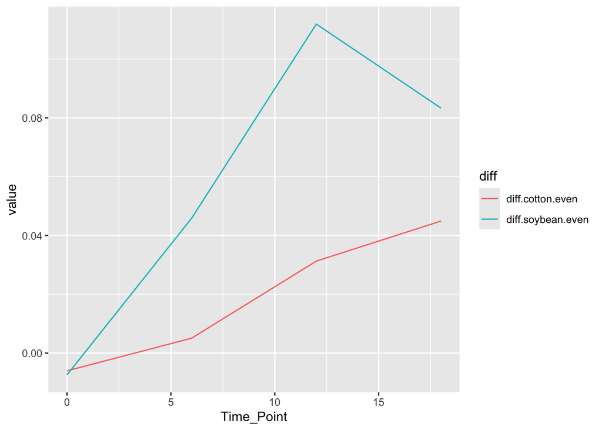

```r
alpha_average2 %>%
  select(Time_Point, diff.cotton.even, diff.soybean.even) %>%
  pivot_longer(c(diff.cotton.even, diff.soybean.even),
names_to = "diff")%>%
  ggplot( aes(x = Time_Point, y = value, color= diff) ) +
  geom_line()
```

[this is my link to directory of coding challenge 5](https://github.com/Radhika-ri/reproducibility/tree/main/CodingChallenge5)